# Brecha de ingreso por hora entre mujeres y hombres con educación superior, por departamento

Proyecto 3 · Narrativa visual integrada · Mapa temático en R

Equipo 3: Alejandro Pardo Costo y Juan Tomás Rincón Pinzón

Noviembre de 2026

# 1 Qué muestra este documento

Este documento construye el mapa del Proyecto 3. El mapa responde a la parte territorial de nuestra pregunta:

> ¿Qué diferencias de ingreso laboral se observan entre mujeres y hombres con educación superior en Colombia (enero–julio 2026) y cómo varían según la edad y **el departamento**?
- **Qué se pinta:** la **brecha de ingreso por hora**. Es el porcentaje que una mujer con educación superior recibe de menos, por cada hora trabajada, frente a un hombre con educación superior del mismo departamento. Por ejemplo, una brecha de 20 % significa que **por cada $ 100 que recibe por hora un hombre, una mujer recibe $ 80**.
- **De dónde sale la cifra:** del notebook de Python (`python/Equipo3_Proyecto3_Analisis.ipynb`, sección 5). Ahí se calcula con los microdatos de la GEIH y el factor de expansión, y se exporta a `datos/procesados/brecha_departamento.csv`. Este documento no recalcula nada, solo lo lleva al mapa.
- **Unidad territorial:** el **departamento** (33 unidades, contando Bogotá). La GEIH no permite dar cifras confiables por municipio, por eso no bajamos a ese nivel.

# 2 Paquetes

```r
library(sf)         # leer y transformar la cartografía
library(dplyr)      # preparar y unir tablas
library(readr)      # leer el CSV que sale de Python
library(ggplot2)    # mapa estático
library(ggspatial)  # barra de escala y flecha de norte
library(classInt)   # clasificación de la variable en intervalos
library(tmap)       # versión interactiva del mapa
```

Si falta alguno, se instala una sola vez con: `install.packages(c("sf", "dplyr", "readr", "ggplot2", "ggspatial", "classInt", "tmap", "rmarkdown", "knitr"))`

# 3 Rutas

El documento está en la carpeta `r/` del repositorio. Al hacer **Knit**, RStudio trabaja desde esa carpeta, así que los datos quedan un nivel arriba (`../datos`). Si alguien lo ejecuta desde la raíz del repositorio, los datos están en `./datos`. La siguiente línea revisa cuál de los dos casos aplica, para no depender de `setwd()`.

```r
BASE <- if (dir.exists("../datos")) ".." else "."

RUTA_MUNICIPIOS <- file.path(BASE, "datos/originales/cartografia/MGN_MPIO_POLITICO.shp")
RUTA_BRECHA     <- file.path(BASE, "datos/procesados/brecha_departamento.csv")
CARPETA_SALIDAS <- file.path(BASE, "r/salidas")
dir.create(CARPETA_SALIDAS, showWarnings = FALSE)

file.exists(c(RUTA_MUNICIPIOS, RUTA_BRECHA))
```

```
## [1] TRUE TRUE
```

# 4 Cartografía: de municipios a departamentos

## 4.1 Lectura y sistema de coordenadas

Usamos el **Marco Geoestadístico Nacional (MGN) del DANE**, capa municipal `MGN_MPIO_POLITICO`, que se entregó en la sesión 02 de R.

```r
municipios <- st_read(RUTA_MUNICIPIOS, quiet = TRUE)

nrow(municipios)          # número de municipios
```

```
## [1] 1121
```

```r
st_crs(municipios)$epsg   # sistema de coordenadas original
```

```
## [1] 4326
```

La capa trae 1121 municipios en coordenadas geográficas WGS84 (EPSG:4326), es decir, en grados de latitud y longitud.

Para dibujar el mapa la pasamos a **MAGNA-SIRGAS / Origen Nacional (EPSG:9377)**. Es la proyección plana oficial de Colombia: las coordenadas quedan en metros, el país no sale estirado y la barra de escala mide bien.

```r
municipios_9377 <- municipios %>%
  st_transform(crs = 9377) %>%
  st_make_valid()    # corrige posibles polígonos mal cerrados antes de unirlos

st_crs(municipios_9377)$epsg
```

```
## [1] 9377
```

## 4.2 Unión de municipios por departamento

La capa no trae departamentos, pero cada municipio tiene su código de departamento (`DPTO_CCDGO`). Al agrupar por ese código y usar `summarise()`, `sf` **une las geometrías** de los municipios y borra los límites internos. Así quedan los 33 departamentos.

Después simplificamos los bordes (`st_simplify`) con una tolerancia de 500 metros. Así el archivo pesa menos y el mapa interactivo carga rápido; a escala nacional la diferencia no se nota. Usamos `preserveTopology = TRUE` para que ninguna isla pequeña (San Andrés, Providencia) desaparezca al simplificar.

```r
departamentos <- municipios_9377 %>%
  group_by(DPTO_CCDGO) %>%
  summarise(n_municipios = n(), .groups = "drop") %>%
  st_simplify(dTolerance = 500, preserveTopology = TRUE)

nrow(departamentos)
```

```
## [1] 33
```

```r
sum(departamentos$n_municipios)   # deben sumar los 1.121 municipios
```

```
## [1] 1121
```

## 4.3 Nombres para mostrar

Los nombres de la capa vienen en mayúsculas y algunos sin tilde (“QUINDIO”), así que escribimos una tabla corta con los nombres como los leería la audiencia. También marcamos si la GEIH en ese departamento **solo encuestó zonas urbanas**. Lo revisamos en los microdatos, con la variable `CLASE` de la tabla de Características generales (1 = cabecera municipal, 2 = centros poblados y rural disperso): en Arauca, Casanare, Putumayo, San Andrés, Amazonas, Guainía, Guaviare, Vaupés y Vichada todos los hogares encuestados están en cabeceras municipales (`CLASE = 1`), no en zona rural.

```r
nombres <- tribble(
  ~DPTO_CCDGO, ~departamento,         ~solo_urbana,
  "05", "Antioquia",             FALSE,
  "08", "Atlántico",             FALSE,
  "11", "Bogotá",                FALSE,
  "13", "Bolívar",               FALSE,
  "15", "Boyacá",                FALSE,
  "17", "Caldas",                FALSE,
  "18", "Caquetá",               FALSE,
  "19", "Cauca",                 FALSE,
  "20", "Cesar",                 FALSE,
  "23", "Córdoba",               FALSE,
  "25", "Cundinamarca",          FALSE,
  "27", "Chocó",                 FALSE,
  "41", "Huila",                 FALSE,
  "44", "La Guajira",            FALSE,
  "47", "Magdalena",             FALSE,
  "50", "Meta",                  FALSE,
  "52", "Nariño",                FALSE,
  "54", "Norte de Santander",    FALSE,
  "63", "Quindío",               FALSE,
  "66", "Risaralda",             FALSE,
  "68", "Santander",             FALSE,
  "70", "Sucre",                 FALSE,
  "73", "Tolima",                FALSE,
  "76", "Valle del Cauca",       FALSE,
  "81", "Arauca",                TRUE,
  "85", "Casanare",              TRUE,
  "86", "Putumayo",              TRUE,
  "88", "San Andrés y Providencia", TRUE,
  "91", "Amazonas",              TRUE,
  "94", "Guainía",               TRUE,
  "95", "Guaviare",              TRUE,
  "97", "Vaupés",                TRUE,
  "99", "Vichada",               TRUE
)

departamentos <- departamentos %>% left_join(nombres, by = "DPTO_CCDGO")
sum(is.na(departamentos$departamento))   # 0 = todos los códigos tienen nombre
```

```
## [1] 0
```

# 5 Datos de la brecha (salida del notebook)

El CSV tiene una fila por departamento. Las columnas que usamos son:

| Columna | Qué es |
| --- | --- |
| `brecha_hora` | Brecha de ingreso por hora, en %: (hombres − mujeres) / hombres × 100 |
| `ic_inf`, `ic_sup` | Margen de error: intervalo de confianza del 95 % (bootstrap de 500 repeticiones por vivienda) |
| `concluyente` | `TRUE` si el intervalo no incluye el 0, es decir, si podemos afirmar que hay diferencia |
| `hora_hombres`, `hora_mujeres` | Ingreso laboral promedio por hora, en pesos |
| `n_hombres`, `n_mujeres` | Personas encuestadas (sin expandir) en la muestra de cada sexo |
| `precision_dane` | Calidad de la estimación según el coeficiente de variación (criterio del DANE) |

El código de departamento se lee como **texto**. Si se leyera como número, “05” (Antioquia) quedaría como 5 y no encontraría su pareja en la cartografía.

```r
brecha <- read_csv(RUTA_BRECHA, col_types = cols(DPTO = col_character()))

nrow(brecha)
```

```
## [1] 33
```

```r
head(brecha, 3)
```

```
## # A tibble: 3 × 14
##   DPTO  n_hombres n_mujeres hora_hombres hora_mujeres brecha_mensual brecha_hora
##   <chr>     <dbl>     <dbl>        <dbl>        <dbl>          <dbl>       <dbl>
## 1 05         2526      3040        21980        18963           18.2        13.7
## 2 08         1682      1737        16742        14834           18.8        11.4
## 3 11         1970      2165        28360        24546           17.6        13.4
## # ℹ 7 more variables: ic_inf <dbl>, ic_sup <dbl>, cv_hombres <dbl>,
## #   cv_mujeres <dbl>, concluyente <lgl>, cv_max <dbl>, precision_dane <chr>
```

# 6 Unión de la tabla con el mapa

Unimos por el código de departamento y verificamos la unión **en los dos sentidos**:

- ningún departamento del mapa se queda sin dato;
- ningún dato se queda sin departamento.

```r
dptos_mapa <- departamentos %>%
  left_join(brecha, by = c("DPTO_CCDGO" = "DPTO"))

sin_dato  <- anti_join(st_drop_geometry(departamentos), brecha, by = c("DPTO_CCDGO" = "DPTO"))
sin_mapa  <- anti_join(brecha, st_drop_geometry(departamentos), by = c("DPTO" = "DPTO_CCDGO"))

nrow(sin_dato)   # departamentos del mapa sin brecha
```

```
## [1] 0
```

```r
nrow(sin_mapa)   # filas del CSV sin polígono
```

```
## [1] 0
```

```r
stopifnot(nrow(sin_dato) == 0, nrow(sin_mapa) == 0)
```

Los 33 departamentos encontraron su pareja. Si la verificación fallara, `stopifnot` detendría el documento en vez de dibujar un mapa con huecos.

# 7 Clasificación de la brecha

## 7.1 Por qué estos cortes

```r
concluyentes <- dptos_mapa %>% filter(concluyente)
nrow(concluyentes)
```

```
## [1] 21
```

```r
range(concluyentes$brecha_hora)
```

```
## [1] 11.40 28.11
```

Hay 21 departamentos con brecha concluyente y 12 sin brecha concluyente. Entre los concluyentes, la brecha va de 11,4 % a 28,1 %.

Usamos **cortes fijos y redondos de 5 en 5: 10, 15, 20 y 25 %**.

- **Son fáciles de leer** para la audiencia: “entre 15 % y 20 %” se entiende mejor que “entre 13,84 % y 16,45 %”, que es lo que darían los cuantiles o *Jenks*.
- **Sirven para comparar con el país.** La brecha nacional es 13,7 %, así que la primera clase (10–15 %) agrupa a los departamentos que están cerca del promedio nacional.
- **No dejan clases vacías.** Ningún departamento concluyente tiene una brecha menor a 10 %, así que empezar en 0 habría gastado dos colores en clases sin departamentos.

Los departamentos **no concluyentes** no entran en la escala de color, porque pintarlos con un tono de brecha sería mostrar una diferencia que los datos no sostienen. Van en **gris**, con su propia entrada en la leyenda.

```r
CORTES <- c(10, 15, 20, 25, 35)

# classInt documenta los intervalos y cuenta cuántos departamentos caen en cada uno
intervalos <- classIntervals(concluyentes$brecha_hora, style = "fixed", fixedBreaks = CORTES)
intervalos
```

```
## style: fixed
##   one of 1,140 possible partitions of this variable into 4 classes
## [10,15) [15,20) [20,25) [25,35]
##       8       6       5       2
```

```r
ETIQUETAS_CLASE <- c("10 % a 15 %", "15 % a 20 %", "20 % a 25 %", "25 % o más")
NO_CONCLUYENTE  <- "No concluyente"

dptos_mapa <- dptos_mapa %>%
  mutate(
    clase = cut(brecha_hora, breaks = CORTES, labels = ETIQUETAS_CLASE, right = FALSE),
    clase = as.character(clase),
    clase = if_else(concluyente, clase, NO_CONCLUYENTE),
    clase = factor(clase, levels = c(ETIQUETAS_CLASE, NO_CONCLUYENTE))
  )

table(dptos_mapa$clase)
```

```
##
##    10 % a 15 %    15 % a 20 %    20 % a 25 %     25 % o más No concluyente
##              8              6              5              2             12
```

## 7.2 Colores

- **Escala secuencial de un solo tono**, el rojo teja que usamos para la brecha en todo el proyecto (`#AD4A3C`): más oscuro significa una brecha más grande.
- **No usamos una escala divergente** porque todos los valores concluyentes son positivos (las mujeres reciben menos). Una escala centrada en 0 dejaría la mitad de los colores sin uso.
- **El gris de “no concluyente”** es más claro y no tiene tono, para que no se confunda con la clase más baja.

```r
PALETA <- c(
  "10 % a 15 %"    = "#F1C1AE",
  "15 % a 20 %"    = "#DC8467",
  "20 % a 25 %"    = "#AD4A3C",
  "25 % o más"     = "#6E2219",
  "No concluyente" = "#E4E4E4"
)
BRECHA_NACIONAL <- 13.7   # brecha por hora nacional, educación superior (notebook, sección 2)
```

# 8 Mapa estático (ggplot2)

## 8.1 Preparación de etiquetas y elementos

Para el mapa usamos estas funciones auxiliares:

- `pct()` escribe los números como se leen en Colombia (coma decimal).
- Las **etiquetas** solo van en los 5 departamentos con la brecha concluyente más alta y en Bogotá, que sirve de referencia. Poner las 33 haría el mapa ilegible; la tabla completa está en la sección 10.
- El **círculo** marca los departamentos donde la GEIH solo encuestó zonas urbanas.

```r
pct <- function(x, decimales = 1) {
  paste0(format(round(x, decimales), nsmall = decimales, decimal.mark = ","), " %")
}

dptos_mapa <- dptos_mapa %>%
  mutate(etiqueta_dato = if_else(concluyente, pct(brecha_hora), "No concluyente"))

a_etiquetar <- dptos_mapa %>%
  filter(concluyente) %>%
  slice_max(brecha_hora, n = 5) %>%
  bind_rows(filter(dptos_mapa, DPTO_CCDGO == "11")) %>%
  mutate(texto = paste0(departamento, "\n", pct(brecha_hora))) %>%
  st_point_on_surface()   # un punto dentro de cada departamento

solo_urbana <- dptos_mapa %>%
  filter(solo_urbana) %>%
  st_point_on_surface()

a_etiquetar$departamento
```

```
## [1] "Guaviare" "Casanare" "Caldas"   "Quindío"  "Meta"     "Bogotá"
```

San Andrés queda a unos 700 km de la costa. Si se dibuja en su posición real, el mapa se encoge para que quepa todo. Por eso el continente se dibuja solo y el archipiélago va en un **recuadro aparte** (a otra escala).

```r
continente <- dptos_mapa %>% filter(DPTO_CCDGO != "88")
caja <- st_bbox(continente)
ancho <- caja["xmax"] - caja["xmin"]
alto  <- caja["ymax"] - caja["ymin"]
```

Las etiquetas de Guaviare, Casanare y Meta caben dentro del departamento. En Guaviare y Casanare las bajamos un poco para no tapar el círculo de “solo urbana”.

Caldas, Quindío y Bogotá son pequeños, así que sus etiquetas van a la izquierda, sobre el océano Pacífico, con una línea que las une a su departamento. Las posiciones se escriben como fracción del ancho y del alto del mapa (0 = borde izquierdo o inferior, 1 = borde derecho o superior).

```r
posiciones <- tribble(
  ~DPTO_CCDGO, ~fx,  ~fy,
  "17",        0.07, 0.64,   # Caldas
  "63",        0.07, 0.53,   # Quindío
  "11",        0.07, 0.43    # Bogotá
)

coordenadas <- st_coordinates(a_etiquetar)
a_etiquetar <- a_etiquetar %>%
  mutate(x = coordenadas[, "X"], y = coordenadas[, "Y"]) %>%
  st_drop_geometry() %>%
  left_join(posiciones, by = "DPTO_CCDGO") %>%
  mutate(
    afuera = !is.na(fx),
    x_etiqueta = if_else(afuera, caja["xmin"] + fx * ancho, x),
    y_etiqueta = case_when(
      afuera      ~ caja["ymin"] + fy * alto,
      solo_urbana ~ y - 0.035 * alto,   # baja la etiqueta para no tapar el círculo
      TRUE        ~ y
    )
  )
```

## 8.2 Recuadro de San Andrés

```r
san_andres <- dptos_mapa %>% filter(DPTO_CCDGO == "88")

recuadro <- ggplot(san_andres) +
  geom_sf(aes(fill = clase), color = "grey35", linewidth = 0.3) +
  geom_sf(data = filter(solo_urbana, DPTO_CCDGO == "88"),
          shape = 21, size = 2.2, stroke = 0.6, fill = NA, color = "grey15") +
  scale_fill_manual(values = PALETA, drop = FALSE, guide = "none") +
  labs(title = paste0("San Andrés y Providencia\n", pct(san_andres$brecha_hora))) +
  theme_void() +
  theme(
    plot.title = element_text(size = 7.5, hjust = 0.5, color = "grey20"),
    panel.border = element_rect(color = "grey60", fill = NA, linewidth = 0.4),
    plot.background = element_rect(fill = "white", color = NA)
  )
```

## 8.3 Mapa principal

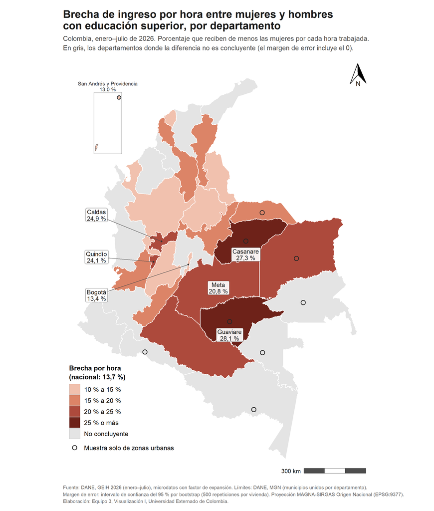

```r
mapa <- ggplot() +
  geom_sf(data = continente, aes(fill = clase), color = "white", linewidth = 0.35) +
  geom_sf(data = filter(solo_urbana, DPTO_CCDGO != "88"),
          aes(shape = "Muestra solo de zonas urbanas"),
          size = 2.6, stroke = 0.7, fill = NA, color = "grey15") +
  geom_segment(
    data = filter(a_etiquetar, afuera),
    aes(x = x, y = y, xend = x_etiqueta, yend = y_etiqueta),
    color = "grey30", linewidth = 0.3
  ) +
  geom_point(data = filter(a_etiquetar, afuera), aes(x = x, y = y), size = 0.8, color = "grey20") +
  geom_label(
    data = a_etiquetar,
    aes(x = x_etiqueta, y = y_etiqueta, label = texto),
    size = 3, lineheight = 0.9, linewidth = 0.2, label.padding = unit(0.18, "lines"),
    fill = alpha("white", 0.92), color = "grey10"
  ) +
  scale_fill_manual(
    values = PALETA, drop = FALSE,
    name = paste0("Brecha por hora\n(nacional: ", pct(BRECHA_NACIONAL), ")")
  ) +
  scale_shape_manual(values = c("Muestra solo de zonas urbanas" = 21), name = NULL) +
  annotation_custom(
    ggplotGrob(recuadro),
    xmin = caja["xmin"], xmax = caja["xmin"] + 0.22 * ancho,
    ymin = caja["ymax"] - 0.20 * alto, ymax = caja["ymax"]
  ) +
  annotation_scale(location = "br", width_hint = 0.25, text_cex = 0.7,
                   bar_cols = c("grey30", "white"), line_width = 0.5) +
  annotation_north_arrow(location = "tr", which_north = "true",
                         height = unit(1.1, "cm"), width = unit(0.8, "cm"),
                         style = north_arrow_orienteering(text_size = 7)) +
  coord_sf(crs = 9377, xlim = c(caja["xmin"], caja["xmax"]),
           ylim = c(caja["ymin"], caja["ymax"]), expand = TRUE, datum = NA) +
  labs(
    title = "Brecha de ingreso por hora entre mujeres y hombres\ncon educación superior, por departamento",
    subtitle = paste0(
      "Colombia, enero–julio de 2026. Porcentaje que reciben de menos las mujeres por cada hora trabajada.\n",
      "En gris, los departamentos donde la diferencia no es concluyente (el margen de error incluye el 0)."
    ),
    caption = paste0(
      "Fuente: DANE, GEIH 2026 (enero–julio), microdatos con factor de expansión. Límites: DANE, MGN (municipios unidos por departamento).\n",
      "Margen de error: intervalo de confianza del 95 % por bootstrap (500 repeticiones por vivienda). ",
      "Proyección MAGNA-SIRGAS Origen Nacional (EPSG:9377).\n",
      "Elaboración: Equipo 3, Visualización I, Universidad Externado de Colombia."
    )
  ) +
  guides(
    fill = guide_legend(order = 1, override.aes = list(color = "grey60", linewidth = 0.2)),
    shape = guide_legend(order = 2)
  ) +
  theme_void(base_size = 11) +
  theme(
    plot.title = element_text(face = "bold", size = 15, color = "grey10", margin = margin(b = 6)),
    plot.subtitle = element_text(size = 9.5, color = "grey30", lineheight = 1.15, margin = margin(b = 10)),
    plot.caption = element_text(size = 7, color = "grey40", hjust = 0, lineheight = 1.15, margin = margin(t = 10)),
    plot.title.position = "plot",
    plot.caption.position = "plot",
    legend.position = "inside",
    legend.position.inside = c(0.02, 0.06),
    legend.justification = c(0, 0),
    legend.title = element_text(size = 9.5, face = "bold", lineheight = 1.1),
    legend.text = element_text(size = 9),
    legend.key.size = unit(0.55, "cm"),
    legend.spacing.y = unit(0.15, "cm"),
    plot.background = element_rect(fill = "white", color = NA),
    plot.margin = margin(14, 14, 10, 14)
  )

mapa
```

## 8.4 Cómo se lee el mapa

- **El color dice cuánto menos reciben por hora las mujeres con educación superior frente a los hombres con educación superior del mismo departamento.** Cuanto más oscuro, mayor es la brecha.
- **El gris no significa “sin brecha”.** Significa que, con la muestra disponible, no podemos afirmar si hay diferencia o no: el margen de error va desde valores negativos hasta positivos.
- **El círculo** advierte que, en ese departamento, la cifra representa solo a las personas que viven en las cabeceras municipales.

**Lo que se observa:**

1. **La brecha concluyente más alta** está en Guaviare (28,1 %) y Casanare (27,3 %). Allí, por cada $ 100 que recibe por hora un hombre con educación superior, una mujer con educación superior recibe cerca de $ 71,90 y $ 72,70. Hay que leer estas dos cifras con cuidado. En ambos departamentos la muestra es solo urbana y pequeña: 319 mujeres y 217 hombres en Guaviare. Por eso el margen de error es ancho: de 15,5 % a 38,7 % en Guaviare.
2. **En el Eje Cafetero la brecha también es alta**: Caldas (24,9 %) y Quindío (24,1 %). Allí la muestra es más grande y el margen de error más estrecho. Le sigue Meta (20,8 %).
3. **Bogotá** tiene una brecha de 13,4 % (margen de error de 8,7 % a 18,6 %). Es muy parecida a la nacional (13,7 %): por cada $ 100 por hora de un hombre, una mujer recibe cerca de $ 86,60.
4. **En 12 departamentos la brecha no es concluyente.** Varios están en la costa Caribe (Córdoba, Sucre, Magdalena, La Guajira) y el Pacífico (Chocó, Cauca, Nariño). Que no sea concluyente no prueba que allí ganen lo mismo: puede que la diferencia sea pequeña o que la muestra no alcance para verla.

**Lo que el mapa NO dice:**

- **No dice que vivir en un departamento *cause* una brecha mayor.** Los departamentos se diferencian en qué sectores emplean, qué carreras estudia la gente y cuántas horas se trabaja. El mapa describe dónde se observa la diferencia, no por qué.
- **El tamaño en el mapa no es el número de personas.** Guaviare ocupa mucho espacio, pero en su muestra hay unas 540 personas con educación superior; Bogotá ocupa poco espacio y en su muestra hay más de 4.100. La tabla de consulta (sección 10) muestra la muestra de cada departamento.

# 9 Margen de error por departamento

El mapa muestra una sola cifra por departamento. Esta figura complementa el mapa: muestra el **margen de error** de cada uno y deja ver por qué algunos quedan en gris.

- **El punto** es la brecha estimada.
- **La línea** es el intervalo del 95 %: el rango en el que, con alta probabilidad, está la brecha real.
- **Si la línea cruza el 0**, el departamento queda en gris en el mapa.

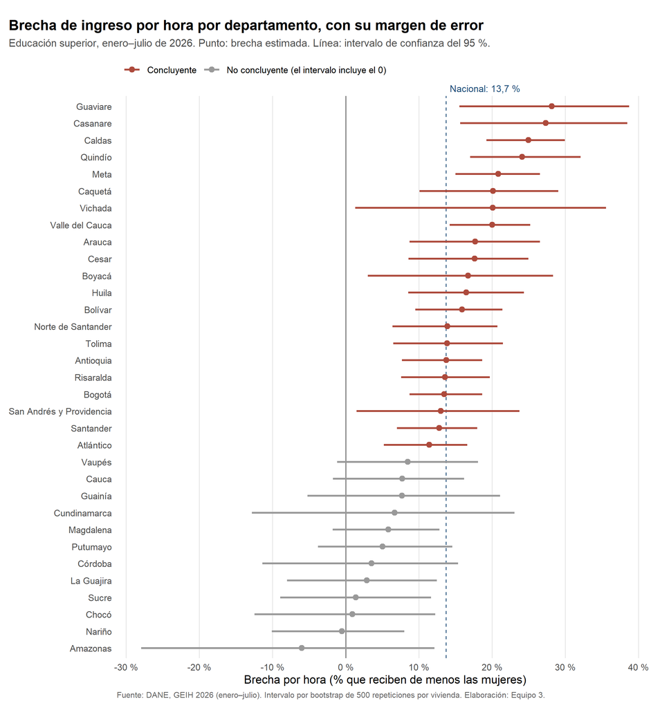

```r
tabla_ic <- dptos_mapa %>%
  st_drop_geometry() %>%
  mutate(
    departamento = factor(departamento, levels = departamento[order(brecha_hora)]),
    tipo = if_else(concluyente, "Concluyente", "No concluyente (el intervalo incluye el 0)")
  )

grafico_ic <- ggplot(tabla_ic, aes(x = brecha_hora, y = departamento, color = tipo)) +
  geom_vline(xintercept = 0, color = "grey40", linewidth = 0.4) +
  geom_vline(xintercept = BRECHA_NACIONAL, color = "#1F4E79", linewidth = 0.4, linetype = "dashed") +
  annotate("text", x = BRECHA_NACIONAL, y = Inf, vjust = -0.6, label = paste0("Nacional: ", pct(BRECHA_NACIONAL)),
           color = "#1F4E79", size = 3, hjust = -0.05) +
  geom_errorbarh(aes(xmin = ic_inf, xmax = ic_sup), height = 0, linewidth = 0.8) +
  geom_point(size = 2.2) +
  scale_color_manual(values = c("Concluyente" = "#AD4A3C",
                                "No concluyente (el intervalo incluye el 0)" = "grey60"),
                     name = NULL) +
  scale_x_continuous(breaks = seq(-30, 40, 10), labels = function(x) paste0(x, " %")) +
  coord_cartesian(clip = "off") +
  labs(
    title = "Brecha de ingreso por hora por departamento, con su margen de error",
    subtitle = "Educación superior, enero–julio de 2026. Punto: brecha estimada. Línea: intervalo de confianza del 95 %.",
    x = "Brecha por hora (% que reciben de menos las mujeres)", y = NULL,
    caption = "Fuente: DANE, GEIH 2026 (enero–julio). Intervalo por bootstrap de 500 repeticiones por vivienda. Elaboración: Equipo 3."
  ) +
  theme_minimal(base_size = 10.5) +
  theme(
    plot.title = element_text(face = "bold", size = 13),
    plot.subtitle = element_text(color = "grey30", size = 9.5),
    plot.caption = element_text(color = "grey40", size = 7.5, hjust = 0),
    plot.title.position = "plot",
    legend.position = "top",
    legend.justification = "left",
    panel.grid.major.y = element_blank(),
    panel.grid.minor = element_blank(),
    plot.margin = margin(18, 14, 8, 8)
  )

grafico_ic
```

Lectura:

- **Los intervalos más anchos** son los de Amazonas, Cundinamarca y Vichada: miden más de 34 puntos porcentuales de punta a punta. Allí la cifra podría cambiar bastante si se repitiera la encuesta con otras viviendas.
- **Los más estrechos** son los de Bogotá, Caldas y Antioquia (unos 10 a 11 puntos), donde se encuestó a más personas.
- **Ningún intervalo concluyente baja de 0**, pero varios están cerca (Vichada y San Andrés empiezan en 1 % a 1,5 %). La cifra puntual de esos departamentos es menos firme que la de Bogotá o Caldas.

# 10 Tabla de consulta

```r
tabla_consulta <- dptos_mapa %>%
  st_drop_geometry() %>%
  arrange(desc(brecha_hora)) %>%
  transmute(
    Departamento = departamento,
    `Brecha por hora` = pct(brecha_hora),
    `Margen de error (IC 95 %)` = paste0(pct(ic_inf), " a ", pct(ic_sup)),
    `¿Concluyente?` = if_else(concluyente, "Sí", "No"),
    `Hora hombres (pesos)` = format(hora_hombres, big.mark = ".", decimal.mark = ","),
    `Hora mujeres (pesos)` = format(hora_mujeres, big.mark = ".", decimal.mark = ","),
    `Muestra H / M` = paste(n_hombres, "/", n_mujeres),
    `Precisión (DANE)` = precision_dane,
    `Solo urbana` = if_else(solo_urbana, "Sí", "")
  )

knitr::kable(tabla_consulta, align = "lrrcrrrcc")
```

| Departamento | Brecha por hora | Margen de error (IC 95 %) | ¿Concluyente? | Hora hombres (pesos) | Hora mujeres (pesos) | Muestra H / M | Precisión (DANE) | Solo urbana |
| --- | --- | --- | --- | --- | --- | --- | --- | --- |
| Guaviare | 28,1 % | 15,5 % a 38,7 % | Sí | 18.781 | 13.502 | 217 / 319 | Aceptable | Sí |
| Casanare | 27,3 % | 15,6 % a 38,5 % | Sí | 21.463 | 15.600 | 293 / 410 | Aceptable | Sí |
| Caldas | 24,9 % | 19,2 % a 29,9 % | Sí | 22.116 | 16.604 | 2102 / 2492 | Precisa |  |
| Quindío | 24,1 % | 17,0 % a 32,1 % | Sí | 21.765 | 16.528 | 1434 / 1623 | Precisa |  |
| Meta | 20,8 % | 15,0 % a 26,5 % | Sí | 20.049 | 15.874 | 1227 / 1441 | Precisa |  |
| Caquetá | 20,1 % | 10,1 % a 29,0 % | Sí | 18.403 | 14.703 | 842 / 1020 | Precisa |  |
| Vichada | 20,1 % | 1,3 % a 35,6 % | Sí | 18.363 | 14.679 | 127 / 166 | Aceptable | Sí |
| Valle del Cauca | 20,0 % | 14,2 % a 25,2 % | Sí | 20.119 | 16.100 | 1878 / 2085 | Precisa |  |
| Arauca | 17,7 % | 8,7 % a 26,5 % | Sí | 14.540 | 11.969 | 148 / 212 | Precisa | Sí |
| Cesar | 17,6 % | 8,6 % a 24,9 % | Sí | 16.825 | 13.865 | 978 / 1212 | Precisa |  |
| Boyacá | 16,7 % | 3,0 % a 28,3 % | Sí | 18.659 | 15.540 | 1412 / 1832 | Precisa |  |
| Huila | 16,4 % | 8,5 % a 24,3 % | Sí | 17.236 | 14.400 | 1163 / 1421 | Precisa |  |
| Bolívar | 15,9 % | 9,5 % a 21,4 % | Sí | 16.613 | 13.978 | 1621 / 1717 | Precisa |  |
| Norte de Santander | 13,9 % | 6,4 % a 20,7 % | Sí | 17.984 | 15.488 | 929 / 1177 | Precisa |  |
| Tolima | 13,8 % | 6,5 % a 21,5 % | Sí | 16.222 | 13.976 | 931 / 1055 | Precisa |  |
| Antioquia | 13,7 % | 7,7 % a 18,6 % | Sí | 21.980 | 18.963 | 2526 / 3040 | Precisa |  |
| Risaralda | 13,5 % | 7,6 % a 19,7 % | Sí | 18.737 | 16.200 | 1791 / 2012 | Precisa |  |
| Bogotá | 13,4 % | 8,7 % a 18,6 % | Sí | 28.360 | 24.546 | 1970 / 2165 | Precisa |  |
| San Andrés y Providencia | 13,0 % | 1,5 % a 23,7 % | Sí | 18.230 | 15.868 | 399 / 599 | Precisa | Sí |
| Santander | 12,8 % | 7,0 % a 18,0 % | Sí | 20.006 | 17.456 | 1925 / 2166 | Precisa |  |
| Atlántico | 11,4 % | 5,2 % a 16,6 % | Sí | 16.742 | 14.834 | 1682 / 1737 | Precisa |  |
| Vaupés | 8,5 % | -1,2 % a 18,0 % | No | 21.660 | 19.826 | 405 / 385 | Precisa | Sí |
| Cauca | 7,7 % | -1,8 % a 16,1 % | No | 15.852 | 14.630 | 1464 / 1626 | Precisa |  |
| Guainía | 7,7 % | -5,2 % a 21,1 % | No | 18.702 | 17.266 | 140 / 162 | Precisa | Sí |
| Cundinamarca | 6,7 % | -12,8 % a 23,0 % | No | 18.559 | 17.322 | 705 / 847 | Aceptable |  |
| Magdalena | 5,8 % | -1,8 % a 12,8 % | No | 13.492 | 12.708 | 1128 / 1298 | Precisa |  |
| Putumayo | 5,0 % | -3,8 % a 14,6 % | No | 17.361 | 16.490 | 168 / 202 | Precisa | Sí |
| Córdoba | 3,5 % | -11,4 % a 15,3 % | No | 16.352 | 15.778 | 892 / 932 | Precisa |  |
| La Guajira | 2,9 % | -8,0 % a 12,4 % | No | 12.871 | 12.500 | 1049 / 1320 | Precisa |  |
| Sucre | 1,4 % | -9,0 % a 11,6 % | No | 15.938 | 15.721 | 1053 / 1164 | Precisa |  |
| Chocó | 0,9 % | -12,5 % a 12,2 % | No | 13.266 | 13.146 | 861 / 1391 | Precisa |  |
| Nariño | -0,5 % | -10,1 % a 8,0 % | No | 15.523 | 15.606 | 1652 / 1910 | Precisa |  |
| Amazonas | -6,0 % | -27,9 % a 12,1 % | No | 16.891 | 17.908 | 105 / 133 | Aceptable | Sí |

La columna **Precisión (DANE)** usa el coeficiente de variación del ingreso por hora de cada sexo. Sigue el criterio del DANE: hasta 7 % es *precisa* y entre 7 % y 15 % es *aceptable*. Todos los departamentos quedan en una de esas dos categorías. Aun así, una estimación precisa del ingreso de cada sexo no garantiza que la **diferencia** entre los dos sea concluyente. Para eso miramos el intervalo.

# 11 Versión interactiva (tmap)

Esta versión es para **consultar** el mapa. Al pasar el cursor aparece el nombre del departamento, y al hacer clic se ven su brecha, el margen de error, la lectura “por cada $ 100” y el tamaño de la muestra. Se puede acercar con la rueda del mouse.

```r
tmap_mode("view")

dptos_interactivo <- dptos_mapa %>%
  mutate(
    `Brecha por hora` = etiqueta_dato,
    `Margen de error (IC 95 %)` = paste0(pct(ic_inf), " a ", pct(ic_sup)),
    `Por cada $ 100 de un hombre, una mujer recibe` =
      if_else(concluyente, paste0("$ ", format(round(100 - brecha_hora, 1), nsmall = 1, decimal.mark = ",")),
              "No se puede afirmar una diferencia"),
    `Ingreso por hora, hombres` = paste0("$ ", format(hora_hombres, big.mark = ".")),
    `Ingreso por hora, mujeres` = paste0("$ ", format(hora_mujeres, big.mark = ".")),
    `Personas en la muestra (H / M)` = paste(n_hombres, "/", n_mujeres),
    `Muestra solo urbana` = if_else(solo_urbana, "Sí", "No")
  )

mapa_interactivo <- tm_shape(dptos_interactivo) +
  tm_polygons(
    fill = "clase",
    fill.scale = tm_scale_categorical(values = unname(PALETA)),
    fill.legend = tm_legend(title = paste0("Brecha por hora (nacional: ", pct(BRECHA_NACIONAL), ")")),
    fill_alpha = 0.85,
    col = "white", lwd = 0.8,
    id = "departamento",
    popup.vars = c("Brecha por hora", "Margen de error (IC 95 %)",
                   "Por cada $ 100 de un hombre, una mujer recibe",
                   "Ingreso por hora, hombres", "Ingreso por hora, mujeres",
                   "Personas en la muestra (H / M)", "Muestra solo urbana")
  ) +
  tm_basemap(NULL)   # sin mapa de fondo: no depende de servicios externos y funciona sin internet

mapa_interactivo
```

[interactive chart not shown]

# 12 Exportación

- El mapa estático se guarda en PNG a 300 ppp para la presentación.
- La figura de intervalos se guarda también en PNG.
- La versión interactiva se guarda como HTML que se abre con doble clic en cualquier navegador.

```r
ggsave(file.path(CARPETA_SALIDAS, "Equipo3_Proyecto3_Mapa_Brecha_Departamento.png"),
       mapa, width = 8.5, height = 10, dpi = 300, bg = "white")

ggsave(file.path(CARPETA_SALIDAS, "Equipo3_Proyecto3_Intervalos_Departamento.png"),
       grafico_ic, width = 8.5, height = 9, dpi = 300, bg = "white")

tmap_save(mapa_interactivo,
          file.path(CARPETA_SALIDAS, "Equipo3_Proyecto3_Mapa_Interactivo.html"),
          selfcontained = TRUE)

list.files(CARPETA_SALIDAS)
```

```
## [1] "Equipo3_Proyecto3_Intervalos_Departamento.png"
## [2] "Equipo3_Proyecto3_Mapa_Brecha_Departamento.png"
## [3] "Equipo3_Proyecto3_Mapa_Interactivo.html"
```

# 13 Limitaciones del mapa

1. **Representatividad territorial.** Juntamos siete meses de encuesta (enero–julio) para tener muestra suficiente por departamento. Aun así, en los departamentos pequeños las muestras son de unos cientos de personas por sexo, y por eso los márgenes de error son anchos.
2. **Cobertura solo urbana en 9 departamentos.** En Arauca, Casanare, Putumayo, San Andrés, Amazonas, Guainía, Guaviare, Vaupés y Vichada, la GEIH solo encuestó cabeceras municipales. El color cubre todo el departamento, pero la cifra no representa a quienes viven en zona rural.
3. **Área no es población.** Un departamento grande llama más la atención aunque tenga pocas personas con educación superior. Por eso acompañamos el mapa con la tabla de muestras y la figura de intervalos.
4. **Todas las edades juntas.** El mapa usa a todas las personas ocupadas con educación superior, no solo a las de 18 a 28 años. Al separar por edad y departamento, varias celdas quedan con menos de 30 hombres jóvenes y las cifras no serían confiables. La diferencia por edad está en el notebook de Python (sección 3).
5. **Descriptivo, no causal.** Las diferencias entre departamentos pueden deberse a la mezcla de sectores, carreras, tamaño de empresa u horas trabajadas. El mapa no separa esas razones.